# Warm-Up 01 Markdown Syntax

Yi Chieh Chen

## **Star Wars** - Griff Halloran

Reference: [Wookieepedia, the Star Wars Wiki](https://starwars.fandom.com/wiki/Griff_Halloran)

[figure not shown]

### A famous quote by Griff Halloran:

> *“It’s been too long since we’ve seen some action.”*

### Physical Description:

| Description | Value |
| --- | --- |
| Species | Human |
| Gender | Male |
| Hair color | Gray |
| Eye color | Gray |
| Skin color | Light |

## **Cooking Recipe** - Vegetarian Dumplings

Reference: [Smitten Kitchen](https://smittenkitchen.com/2007/02/on-obsessiveness-and-ollies/)

You can also get to the website by clicking the photo below!

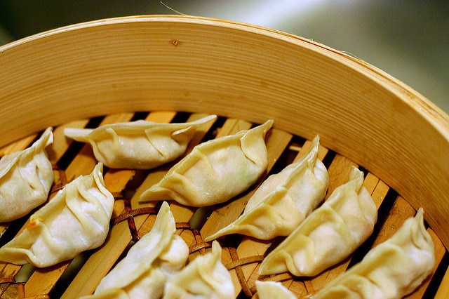

### Ingredients:

- 1/2 pound firm tofu
- 1/2 cup coarsely grated carrots
- 1/2 cup shredded Napa cabbage
- 2 tablespoons finely chopped red pepper
- 2 tablespoons finely chopped scallions
- 2 teaspoons finely minced fresh ginger
- 1 tablespoon chopped cilantro leaves
- 2 minced cloves garlic
- 1 tablespoon soy sauce
- 1 tablespoon hoisin sauce
- 2 teaspoons toasted sesame oil  
  (could replace 1 teaspoon with hot sesame oil - delicious)
- 1 egg, lightly beaten
- 1 teaspoon kosher salt
- 1/4 teaspoon freshly ground black pepper
- 35 to 40 small wonton wrappers
- 1/3 cup chicken stock or water

### Special Kitchen Tools:

- 1 sheet pan
- 1 damp cloth
- 1 heatproof platter

### Steps:

1. Preheat the oven to 200°F.
2. Cut the tofu in half horizontally and lay between layers of paper towels. Place on a plate, top with another plate, and place a weight on top (a 14-ounce can of vegetables works well). Let stand 20 minutes. After 20 minutes, cut the tofu into 1/4-inch cubes and place in a large mixing bowl. Add the carrots, cabbage, red pepper, scallions, ginger, cilantro, soy sauce, hoisin, sesame oil, egg, salt, and pepper. Lightly stir to combine.
3. To form the dumplings, remove 1 wonton wrapper from the package, covering the others with a damp cloth. Brush the edges of the wrapper lightly with water. Place 1/2 rounded teaspoon of the tofu mixture in the center of the wrapper. Shape as desired*. Set on a sheet pan and cover with a damp cloth. Repeat procedure until all of the filling is gone.
4. Heat a 12-inch saute pan over medium heat. Brush with vegetable oil once hot. Add 8 to 10 potstickers at a time to the pan and cook for 2 minutes, without touching. Once the 2 minutes are up, gently add 1/3 cup chicken stock to the pan, turn the heat down to low, cover, and cook for another 2 minutes.
5. Remove wontons to a heatproof platter and place in the warm oven. Repeat until all the wontons are cooked.
6. Serve immediately.

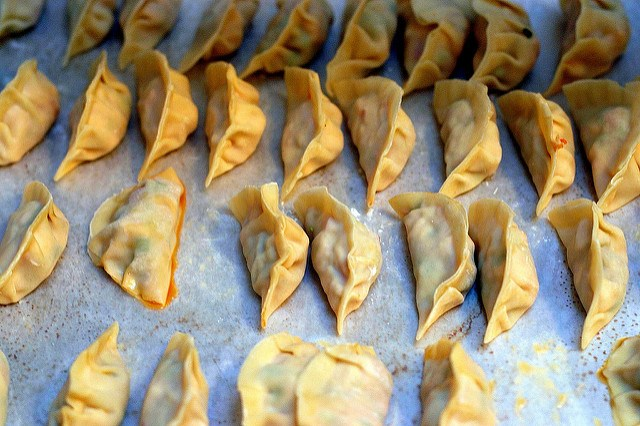

[figure not shown]

### Is there a special season of the year for it?

No!

### Are there variations of the recipe? Using other ingredients?

You may want to try [Spring Vegetable Potstickers](https://smittenkitchen.com/2007/02/on-obsessiveness-and-ollies/)!  
For the “spring” part, asparagus and favas were used in this recipe. However, this is a flexible recipe, so don’t fret if you don’t have the exact ingredient list. You should use a mix of whatever vegetables look awesome right now.

## **Euclidean Distance**

Reference: [Euclidean Distance](https://en.wikipedia.org/wiki/Euclidean_distance)

### Definition

The **Euclidean distance** between points **p** and **q** is the length of the line segment connecting them ($\overline{\textbf{pq}}$).

In [Cartesian coordinates](https://en.wikipedia.org/wiki/Cartesian_coordinate_system), if **p** = ($p_1, p_2,..., p_n$) and **q** = ($q_1, q_2,..., q_n$) are two points in Euclidean *n*-space, then the distance (d) from **p** to **q**, or from **q** to **p** is given by the [Pythagorean formula](https://en.wikipedia.org/wiki/Pythagorean_theorem):

$\begin{align*} d(\textbf{p},\textbf{q})=d(\textbf{q},\textbf{p}) &= \sqrt{(q_1-p_1)^2+(q_2-p_2)^2+\dots+(q_n-p_n)^2}\hspace{8.5cm}(1)\\ &= \sqrt{\displaystyle\sum_{i=1}^{n}(q_i-p_i)^2}. \end{align*}$

The position of a point in a Euclidean n-space is a [Euclidean vector](https://en.wikipedia.org/wiki/Euclidean_vector). So, **p** and **q** may be represented as Euclidean vectors, starting from the origin of the space (initial point) with their tips (terminal points) ending at the two points. The **Euclidean norm**, or **Euclidean length**, or **magnitude** of a vector measures the length of the vector:

$\begin{equation} \|\textbf{p}\| = \sqrt{p_1^2 + p_2^2 + \dots + p_n^2} = \sqrt{\textbf{p.p}}, \end{equation}$

where the last expression involves the [dot product](https://en.wikipedia.org/wiki/Dot_product).